# WiSTEM 2022 - 2023

## Most and Least Popular Careers

**Distribution:** In the folded blue tabs below, the most and least commonly written majors were identified in the Pre and Post-Test responses. For the Pre-Test, the three most common were Engineer (8.04%), Chemist (6.97%), and Doctor (6.97%) while for the Post-Test, the three most common were Doctor (8.00%), Engineer (8.00%), but also Biologist (6.00%). In the third foldable tab, there are lists of unique career options that were only in the Pre-Test or only in the Post-Test as well as another list of careers that were present in both forms.

**Pre Test: Most and Least Common**

**Most Common Careers in the Pre-Test**

Most Common Career Chosen in Pre Test

| Type | Career | Count | Proportion | Percent |
| --- | --- | --- | --- | --- |
| pre | Engineer | 30 | 0.0804290 | 8.042895 |
| pre | Chemist | 26 | 0.0697051 | 6.970509 |
| pre | Doctor | 26 | 0.0697051 | 6.970509 |
| pre | Biologist | 20 | 0.0536193 | 5.361930 |
| pre | Physicist | 17 | 0.0455764 | 4.557641 |
| pre | Scientist | 16 | 0.0428954 | 4.289544 |
| pre | Mathematician | 15 | 0.0402145 | 4.021448 |
| pre | Programmer | 14 | 0.0375335 | 3.753351 |
| pre | Architect | 13 | 0.0348525 | 3.485255 |
| pre | Bioengineer | 11 | 0.0294906 | 2.949062 |

**Least Common Careers in the Pre-Test**

```
Careers that were chosen only once:
```

```
 [1] "Anesthesiologist"       "Anthropologist"         "Astrobiologist"
 [4] "Biomedical Engineer"    "Biotechnician"          "Cardiovascular Surgeon"
 [7] "Computer Engineer"      "Cybersecurity"          "Data Analyst"
[10] "Data Scientist"         "Economist"              "Entrepreneur"
[13] "Environmentalist"       "Financial Risk Analyst" "Geologist"
[16] "Gynecologist"           "Manufacturer"           "Materials Engineer"
[19] "Meteorologist"          "Metrologist"            "Nueroscientist"
[22] "Nuerosurgeon"           "Ornithologist"          "Orthopedic Surgeon"
[25] "Pediatric Surgeon"      "Pediatrician"           "Pharmacist"
[28] "Physician"              "Product Designer"       "Pulmonologist"
[31] "Rocket Scientist"       "Structural Engineer"    "Teacher"
[34] "Technician"
```

```
Careers that were chosen only two or three times:
```

```
 [1] "Astronaut"              "Cardiologist"           "Cardiothoracic Surgeon"
 [4] "Construction Worker"    "Industrial Engineer"    "Microbiologist"
 [7] "Psychiatrist"           "Archeologist"           "Artist"
[10] "Computer Technician"    "Dentist"                "OB-GYN"
[13] "Vet"
```

**Post Test: Most and Least Common**

**Most Common Careers in the Post-Test**

Most Common Career Chosen in Post Test

| Type | Career | Count | Proportion | Percent |
| --- | --- | --- | --- | --- |
| post | Doctor | 16 | 0.080 | 8.0 |
| post | Engineer | 16 | 0.080 | 8.0 |
| post | Biologist | 12 | 0.060 | 6.0 |
| post | Mechanical Engineer | 9 | 0.045 | 4.5 |
| post | Chemist | 8 | 0.040 | 4.0 |
| post | Computer Scientist | 8 | 0.040 | 4.0 |
| post | Physicist | 8 | 0.040 | 4.0 |
| post | Aerospace Engineer | 7 | 0.035 | 3.5 |
| post | Biomedical Engineer | 7 | 0.035 | 3.5 |
| post | Mathematician | 7 | 0.035 | 3.5 |

**Least Common Careers in the Post-Test**

```
Careers that were chosen only once:
```

```
 [1] "AI Developer"           "Accountant"             "Anesthesiologist"
 [4] "Biochemist"             "Data Analyst"           "Dentist"
 [7] "Dermatologist"          "Environmental Engineer" "Geneticist"
[10] "Industrial Engineer"    "Mechanic"               "Metrologist"
[13] "Microbiologist"         "Nuclear Engineer"       "Nutritionist"
[16] "Paramedic"              "Psychiatrist"           "Radiologist"
[19] "Software Engineer"      "Vet"
```

```
Careers that were chosen only two or three times:
```

```
 [1] "Astrophysicist"       "Bioengineer"          "Computer Engineer"
 [4] "Electrical Engineer"  "Epidemiologist"       "Marine Biologist"
 [7] "Math Teacher"         "Orthopedic Surgeon"   "Pediatrician"
[10] "Pharmacist"           "Psychologist"         "Researcher"
[13] "Statistician"         "Architect"            "Astronomer"
[16] "Biochemical Engineer" "Programmer"
```

**Difference Between Pre and Post-Test Career Choices**

**Change in Careers**

```
New careers present in the pre-test, but not post-test:
```

```
 [1] "Anthropologist"         "Archeologist"           "Artist"
 [4] "Astrobiologist"         "Astronaut"              "Biotechnician"
 [7] "Cardiologist"           "Cardiothoracic Surgeon" "Cardiovascular Surgeon"
[10] "Computer Technician"    "Construction Worker"    "Cybersecurity"
[13] "Data Scientist"         "Economist"              "Entrepreneur"
[16] "Environmentalist"       "Financial Risk Analyst" "Geologist"
[19] "Gynecologist"           "Manufacturer"           "Materials Engineer"
[22] "Meteorologist"          "Nueroscientist"         "Nuerosurgeon"
[25] "OB-GYN"                 "Ornithologist"          "Pediatric Surgeon"
[28] "Physical Therapist"     "Physician"              "Product Designer"
[31] "Pulmonologist"          "Rocket Scientist"       "Structural Engineer"
```

```
Careers present in the post-test, but not pre-test:
```

```
 [1] "AI Developer"         "Biochemical Engineer" "Computer Scientist"
 [4] "Dermatologist"        "Electrical Engineer"  "Epidemiologist"
 [7] "Geneticist"           "Nuclear Engineer"     "Nutritionist"
[10] "Paramedic"            "Radiologist"          "Statistician"
```

**Constant Careers**

```
The same careers present in both the pre and post-tests:
```

```
 [1] "Accountant"             "Aerospace Engineer"     "Anesthesiologist"
 [4] "Architect"              "Astronomer"             "Astrophysicist"
 [7] "Biochemist"             "Bioengineer"            "Biologist"
[10] "Biomedical Engineer"    "Chemical Engineer"      "Chemist"
[13] "Civil Engineer"         "Computer Engineer"      "Data Analyst"
[16] "Dentist"                "Doctor"                 "Engineer"
[19] "Environmental Engineer" "Industrial Engineer"    "Marine Biologist"
[22] "Math Teacher"           "Mathematician"          "Mechanic"
[25] "Mechanical Engineer"    "Metrologist"            "Microbiologist"
[28] "Neuroscientist"         "Nurse"                  "Orthopedic Surgeon"
[31] "Pediatrician"           "Pharmacist"             "Physicist"
[34] "Programmer"             "Psychiatrist"           "Psychologist"
[37] "Researcher"             "Scientist"              "Software Developer"
[40] "Software Engineer"      "Surgeon"                "Teacher"
[43] "Technician"             "Vet"
```

## Career Major Categories

**Distribution:** It is known that students collaborated on this question at times so that’s why some careers appear more often than others. However, in this section, every career option was considered only once, no matter how many students. actually wrote it down either on the Pre-Test or Post-Test. The table below groups all of the careers students wrote down by what major they would relate to in college. Out of all the 77 unique careers seen in the Pre-Test and the 56 found in the Post-Test, most careers would fall under “Medical” or “Pre-Med” majors in undergrad.

Careers Grouped by Major Category

| Category | Count (Pre) | Count (Post) | Percent (Pre) | Precent (Post) |
| --- | --- | --- | --- | --- |
| Medical | 26 | 20 | 33.766234 | 35.714286 |
| Engineer | 13 | 15 | 16.883117 | 26.785714 |
| Physics | 6 | 3 | 7.792208 | 5.357143 |
| Computer Science | 6 | 5 | 7.792208 | 8.928571 |
| Psych/Neuro | 5 | 3 | 6.493506 | 5.357143 |
| Miscellaneous | 5 | 4 | 6.493506 | 7.142857 |
| Business | 4 | 1 | 5.194805 | 1.785714 |
| History | 2 | 0 | 2.597403 | 0.000000 |
| Math | 2 | 3 | 2.597403 | 5.357143 |
| Earth Studies | 2 | 0 | 2.597403 | 0.000000 |
| Design Studies | 2 | 0 | 2.597403 | 0.000000 |
| Education | 2 | 2 | 2.597403 | 3.571429 |
| Arts | 1 | 0 | 1.298701 | 0.000000 |
| Legal Studies | 1 | 0 | 1.298701 | 0.000000 |

## Career STEM Categories

**Distribution:** This time, the career options that were written down were grouped by which category under STE(A)M they would fall under. In the end, the majority of careers would be under the “Science” branch, being 61% of career options on the Pre-Test and 54% of the career options on the Post-Test. This is while on the Post-Test, there were no careers that would fall under the “Arts” branch even though 4% of the careers did in the Pre-Test. Besides that, the follow up for the next most common branch for the careers to fall under was “Engineering”, being 17% of the careers for the Pre-Test and 27% for the Post-Test.

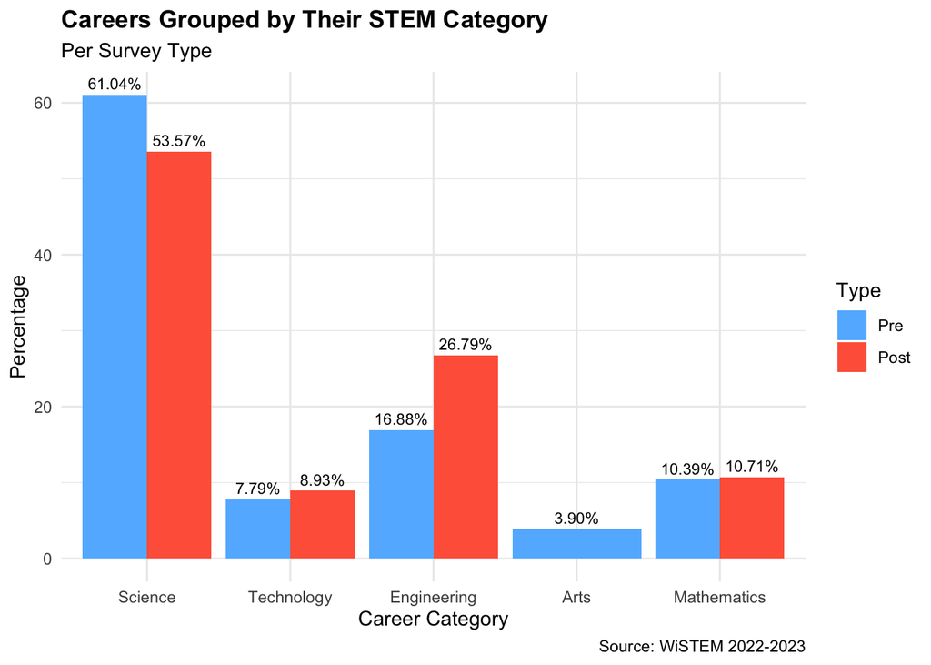

**Table for Careers Grouped by STEM Type**

Careers Grouped by STEM Type Per Survey Type

| Category | Type | Count | Percentage |
| --- | --- | --- | --- |
| Science | pre | 47 | 61.038961 |
| Science | post | 30 | 53.571429 |
| Engineering | pre | 13 | 16.883117 |
| Engineering | post | 15 | 26.785714 |
| Mathematics | pre | 8 | 10.389610 |
| Mathematics | post | 6 | 10.714286 |
| Technology | pre | 6 | 7.792208 |
| Technology | post | 5 | 8.928571 |
| Arts | pre | 3 | 3.896104 |